# UNICEF P3 Technical Evaluation

### Task 1: Maternal and Child Health Indicators Analysis

##### *Q. Your task is to calculate population-weighted coverage of health services (antenatal care and skilled birth attendance) for countries categorized as on-track and off-track in achieving under-5 mortality targets as of 2023.*

As SDG IGME classification is based on how close countries are to their targets, it is expected that the values of the indicators are highest for countries that have already met the target, followed by those on track, and finally, the mean estimates decline for countries where acceleration is needed. This expected trend is evident in the figure showing the percentage of deliveries attended by skilled health personnel. However, for the indicator ‘percentage of women (aged 15-49 years) attended at least four times during pregnancy by any provider,’ the difference is large between the achieved category and the other two categories (on track and acceleration needed). In fact, the differences in mean values between the on track and acceleration needed categories are small and not statistically significant.

Percentage of women (aged 15-49 years) attended at least four times during pregnancy by any provider

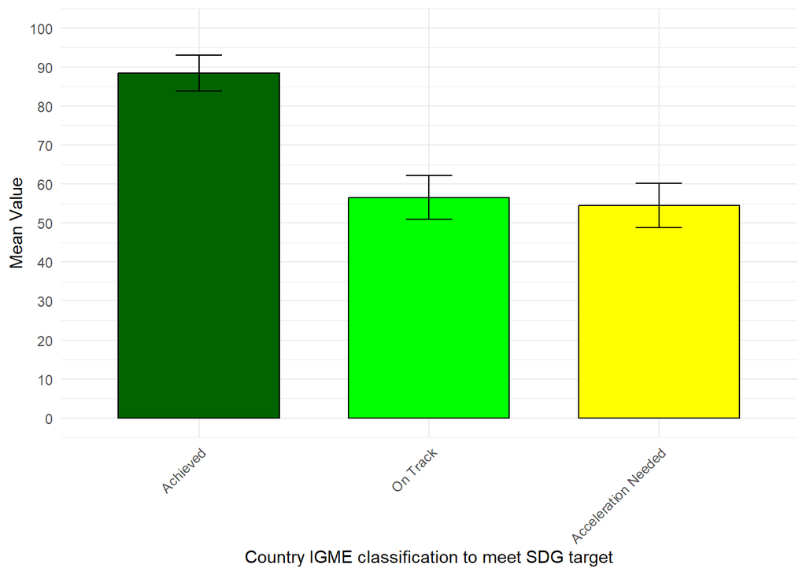

Percentage of deliveries attended by skilled health personnel

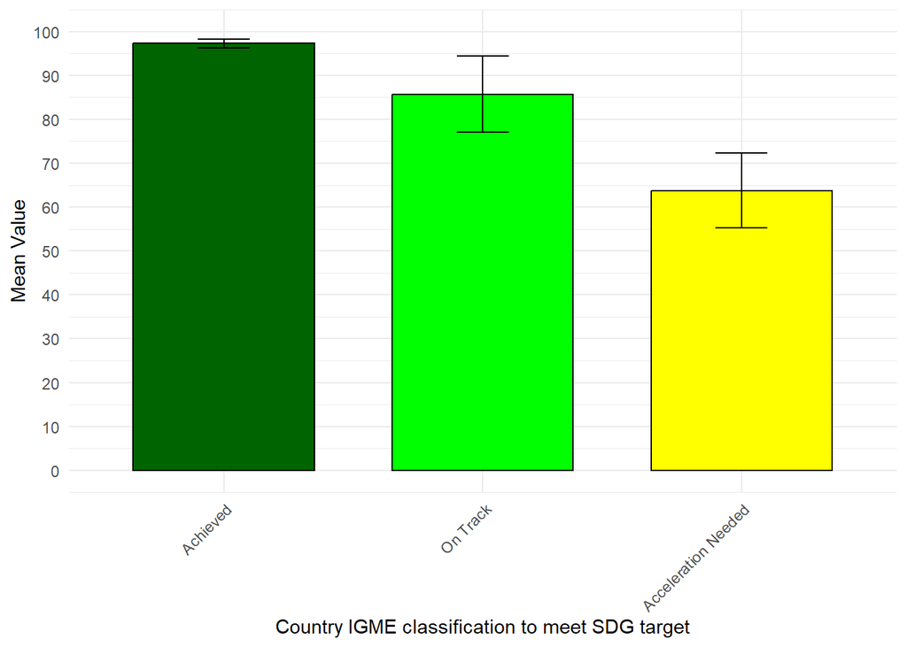

### Task 2: Data Perspectives: Zimbabwe MICS Early childhood development data

This data perspective addresses two components of Task 2 assigned in this assessment:

1. Readme.md: wherein a technical exploration of the data was requested.
2. Readme.html: wherein a series of activities were assigned including the calculation of a new index using the mean across the variables provided in the data was requested.

To fulfill the first component, this data perspective analyzes the Early Childhood Development Index (ECDI) as calculated for Zimbabwe, specifically presenting reliability estimates of the domains and overall score, and suggesting a way forward. The second component addresses the questions listed in the HTML, with figures and tables integrated into the narrative.

The dataset provided contains 2,517 observations from the 2019 Zimbabwe MICS, of which 26 do not have any information on the date of birth. Since this analysis focuses on age in months, these 26 observations were excluded, resulting in a total of 2,491 observations, as shown in the table1 below*

Summary of Observations by Child's Age with Missing Values

| Child Age (Years) | Total Observations in the dataset | Obs misssing in 'child_birtday' | Non-missing obs in 'child_birthday' | Missing Values |
| --- | --- | --- | --- | --- |
| 3 | 1224 | 15 | 1209 | TRUE |
| 4 | 1293 | 11 | 1282 | TRUE |

For the analysis, items EC6 to EC15 were recoded as binary variables. The coding depends on the context of the item: - For positive items (where the question asks whether the child is able to perform a task), responses were coded as 1 for “Yes” and 0 otherwise. - Exceptions include items EC10, EC14, and EC15, where the questions are framed negatively. These items were recoded as 1 if the response was “No” and 0 otherwise.

##### *MICS ECDI*

In Zimbabwe, the MICS collected information on early childhood development using the 10 items provided in the dataset, which contribute to an overall score called the ECDI score. According to [UNICEF guidelines](https://mics.unicef.org/files?job=W1siZiIsIjIwMTcvMDkvMTUvMjEvMTUvNDMvMzc4L01JQ1NfTWV0aG9kb2xvZ2ljYWxfUGFwZXJfNi5wZGYiXV0&sha=85c096f0b2c5b0c8), the primary purpose of the ECDI score is to understand the normative distribution of children’s developmental status in the countries where it is implemented. The ECDI is administered to the mother or caregiver of the child and should not be interpreted as the child’s performance on the items.

**ECDI items and domains**

| **Variable name** | **Item** | **Domain** |
| --- | --- | --- |
| EC6 | Can (name) identify or name at least ten letters of the alphabet? | Literacy and numeracy domainCut-off score: 2 on 3 |
| EC7 | Can (name) read at least four simple, popular words? |  |
| EC8 | Does (name) know the name and recognize the symbol of all numbers from 1 to 10? |  |
| EC9 | Can (name) pick up a small object with two fingers, like a stick or a rock from the ground? | Physical domain Cut-off score: 1 on 2 |
| EC10 | Is (name) sometimes too sick to play? |  |
| EC11 | Does (name) follow simple directions on how to do something correctly? | Learn domain Cut-off score: 1 on 2 |
| EC12 | When given something to do, is (name) able to do it independently? |  |
| EC13 | Does (name) get along well with other children? | Social and emotional domain Cut-off score: 2 on 3 |
| EC14 | Does (name) kick, bite, or hit other children or adults? |  |
| EC15 | Does (name) get distracted easily? |  |

The index is based on selected milestones that children are expected to achieve by ages 3 and 4. These ten items are grouped into four domains: literacy and numeracy, physical, social and emotional, and learning. The table below maps the domains to the corresponding items and provides the cut-off scores for determining whether a child is developmentally on track in each domain. If a child is developmentally on track in three or four domains, they are assigned an ECDI score of 1; otherwise, they receive a score of 0.

The dataset provided includes each of the variables for ECDI as well as the age variable. Table 3 (Task HTML, 2c)below provides a summary statistics of share of children 3 and 4 by each item.

Summary Statistics by Child Age Years

| Child Age (in years) | Number of Observations | Percent reported to be able to Identify or name at least ten letters of the alphabet (EC6) | Percent reported to be able to Read at least four simple, popular words (EC7) | Percent reported to be able to Know the name and recognize the symbol of all numbers from 1 to 10 (EC8) | Percent reported to be able to Pick up a small object (EC9) | Percent reported to be able to Not be 'sometimes too sick to play' (EC10) | Percent reported to be able to Follow simple directions (EC11) | Percent reported to be able to Follow direction independently (EC12) | Percent reported to be able to Get along with other children (EC13) | Percent reported to be able to Not kick, bite, or hit other children or adults (EC14) | Percent reported to be able to Not get distracted easily (EC15) |
| --- | --- | --- | --- | --- | --- | --- | --- | --- | --- | --- | --- |
| 3 | 1209 | 6.4 | 7.8 | 11.1 | 90.7 | 59.8 | 83.8 | 70.9 | 95.7 | 49.0 | 61.5 |
| 4 | 1282 | 14.0 | 13.3 | 25.0 | 92.7 | 62.2 | 89.0 | 76.5 | 96.3 | 52.7 | 63.3 |

Table 3 shows that the majority of children are reported to get along with others (95.7% at age 3 and 96.3% at age 4) and can pick up small objects (90.7% at age 3 and 92.7% at age 4). Conversely, fewer children are reported to demonstrate skills in items associated with literacy and numeracy domain, with the most significant age-related differences observed in these areas. Notably, the percentage of children able to perform tasks in the literacy and numeracy domain (items EC6, EC7, and EC8) nearly doubles between ages 3 and 4.

Across all items, the ability of children to perform tasks increases with age, which is also supported by regression analysis (Table 4, task HTML 2g). Table 4 presents the results of the regression analysis requested in the Readme.html task for the Readme.html ECDI score as the dependent variable and age as independent variable. The results indicate that age in months is statistically significant, with older children more likely to achieve a higher score. However, age explains only 3% of the variability in the score, suggesting that the model has weak explanatory power.

**Regression Results**

|  | *Dependent variable:* |
| --- | --- |
| **Age in Months** | .004*** (.0004) |
| **Constant** | .39*** (.02) |
| **Observations** | 2,491 |
| **R**<sup>2</sup> | .03 |
| **Adjusted R**<sup>2</sup> | .02 |
| *Note:* | *p<0.1; **p<0.05; ***p<0.01 |

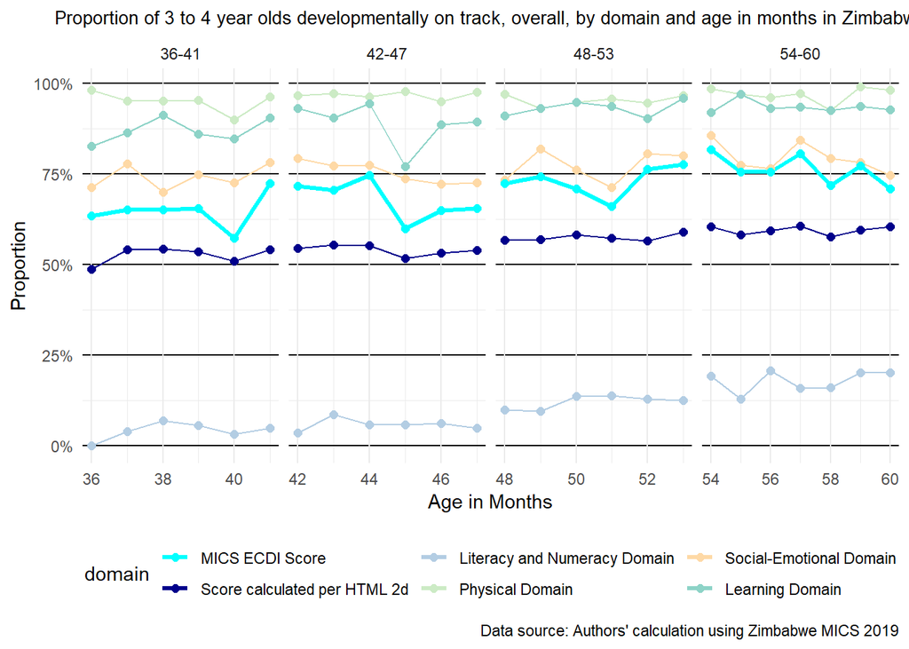

1. Majority of children are on track in three domains and children who are on track in three domains almost always include the physical, socio-emotional domains or learning domains in their profile. Additionally, due to relatively high reporting on physical, social-emotional and learning domains, few children fall in the categories on being on track in one or two domains only.
2. Children who are only on track in one or two domains rarely includes being on track in literacy and numeracy. But among children who are on track in four domains literary and numeracy domain contributes equally.

Sankey diagram linking domains with number of targets met

[interactive chart not shown]

##### *ECDI: Reliability in the Zimbabwean context?*

The ECDI instrument underwent [rigorous validation](https://mics.unicef.org/files?job=W1siZiIsIjIwMTcvMDkvMTUvMjEvMTUvNDMvMzc4L01JQ1NfTWV0aG9kb2xvZ2ljYWxfUGFwZXJfNi5wZGYiXV0&sha=85c096f0b2c5b0c8) in 4 countries in 2 phases before its inclusion in the MICS surveys. However, even a valid tool may not always yield reliable results across different contexts. Reliability may be impacted by a number of factors including cultural variations, different interpretations of questions, or varying levels of exposure to early childhood development activities.

Table: Reliability analysis and number of observations

| Domain | Reliability Analysis Cohort | Reliability Analysis Cronbach's Alpha | Reliability Analysis Standardized Alpha | Reliability Analysis Average Item Correlation | Reliability Analysis Observations |
| --- | --- | --- | --- | --- | --- |
| HTML Readme based index | 3 to 4 year olds | 0.45 | 0.48 | 0.08 | 2491 |

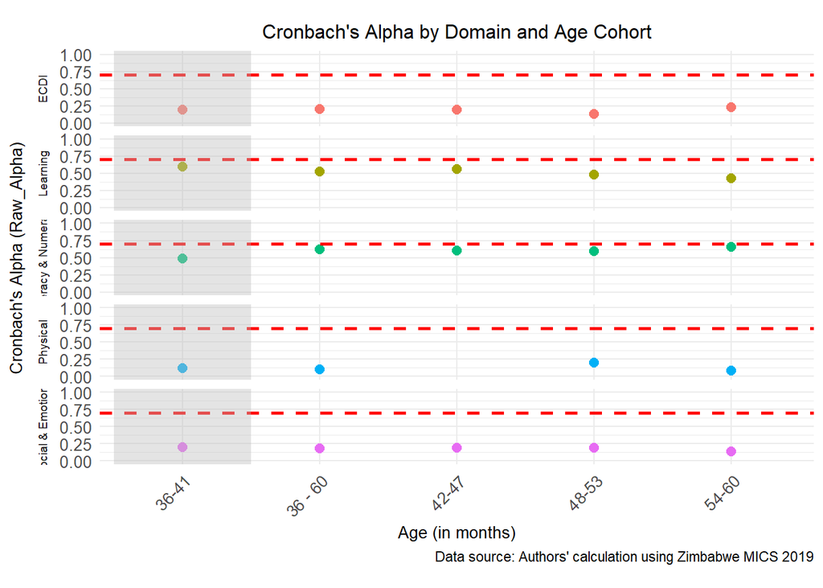

**Note:** physical domain items EC9 and EC10 were negatively correlated for 42 to 47 month olds and were dropped. Further investigation is recommended to understand these.

In the Zimbabwean context, the Cronbach’s alpha for the ECDI score, the HTML-index score, and the physical and socio-emotional domains indicates unacceptable reliability i.e. they are below 0.50 for all age groups analyzed.This suggests that the items are not sufficiently correlated to form a reliable scale within this context.

Several factors could be contributing this and further analysis is needed to understand thes. For example, re-testing items in similar contexts or conducting sensitivity analyses to assess item heterogeneity (i.e., whether the items are effectively measuring the intended constructs) may provide additional insights. Additionally, the low number of items per domain might contribute to the scale’s instability.

UNICEF has anticipated these challenges and launched a new ECDI2030 (https://data.unicef.org/resources/early-childhood-development-index-2030-ecdi2030/) , rolled out in 2021, which includes methodological improvements such as an increased number of items per domain. While both ECDI and ECDI2030 have undergone rigorious methodological development and are valid, it will be crucial to conduct reliability analysis on this new tool to maintain credibility of analysis using these measures as any conclusions drawn using unreliable measures could be flawed or misleading reading their policy value.